# ChIP-seq analysis workflow with gVenn using A549 datasets: identifying binding site overlaps

# 9 Export overlap groups

Each overlap group (e.g., `group_100`, `group_110`, `group_111`) can be exported for downstream analysis. The gVenn package provides two export functions depending on your data type and downstream needs:

## 9.1 For all overlap types (genomic or gene sets):

The function `exportOverlaps()` writes each group to an Excel file with one sheet per overlap group, making it easy to review and reuse the results outside of R.

```r
# export overlaps to Excel file
exportOverlaps(groups,
               output_dir = ".",
               output_file = "overlap_groups")
```

## 9.2 For genomic overlaps only:

When working with genomic regions (GRanges objects), you can export overlap groups as BED files using `exportOverlapsToBed()`. This creates one BED file per overlap group, which is ideal for visualization in genome browsers (IGV, UCSC Genome Browser) or for downstream analyses requiring BED format input.

```r
# Export genomic overlaps to BED files
exportOverlapsToBed(groups,
                    output_dir = ".",
                    output_prefix = "overlaps",
                    with_date = FALSE)

# This will create separate BED files such as:
# - overlaps_group_100.bed
# - overlaps_group_110.bed
# - overlaps_group_111.bed
# etc.
```

# 10 Customization examples

This section shows common ways to customize the Venn diagram produced by `plotVenn()`.

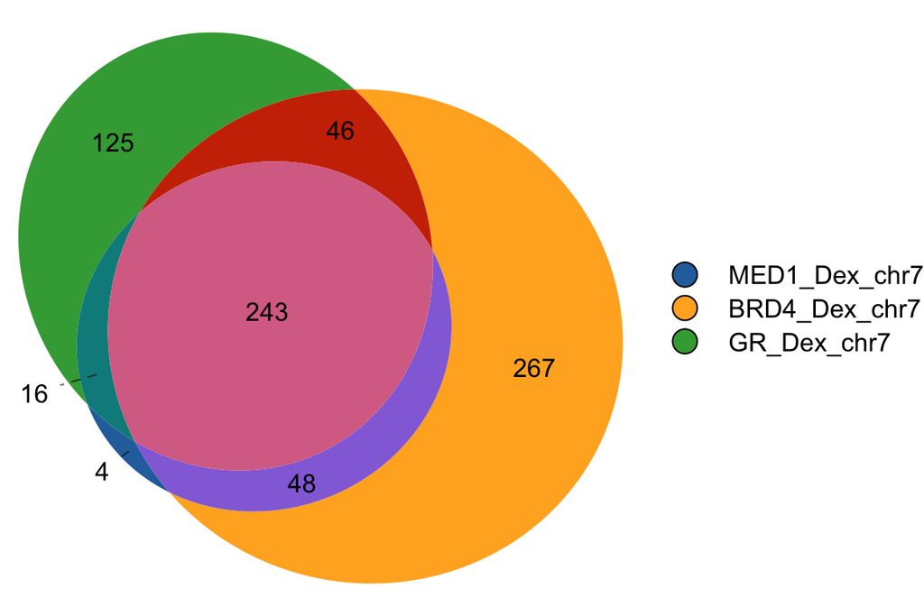

```r
# basic default venn plot (uses package defaults)
plotVenn(genomic_overlaps)
```

## 10.1 Custom fills with transparency

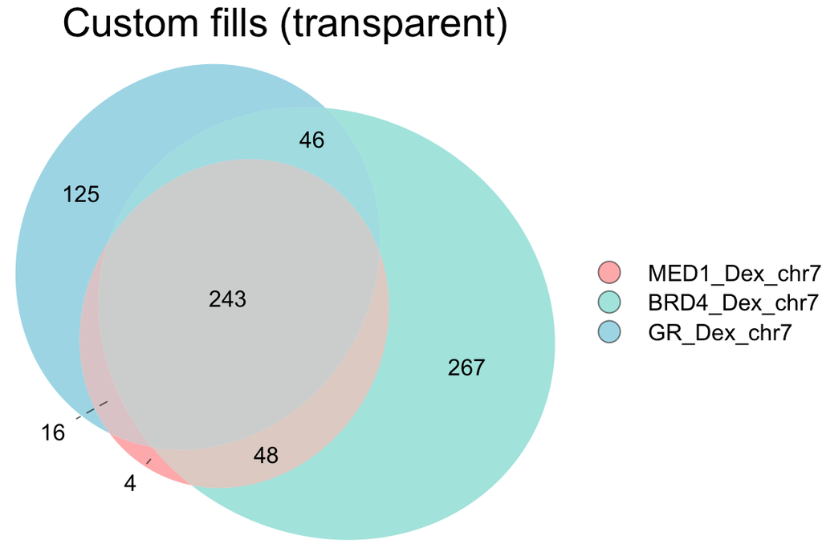

```r
plotVenn(genomic_overlaps,
         fills = list(fill = c("#FF6B6B", "#4ECDC4", "#45B7D1"), alpha = 0.5),
         legend = "right",
         main = list(label = "Custom fills (transparent)", fontsize = 14))
```

## 10.2 Colored edges, no fills (colored borders only)

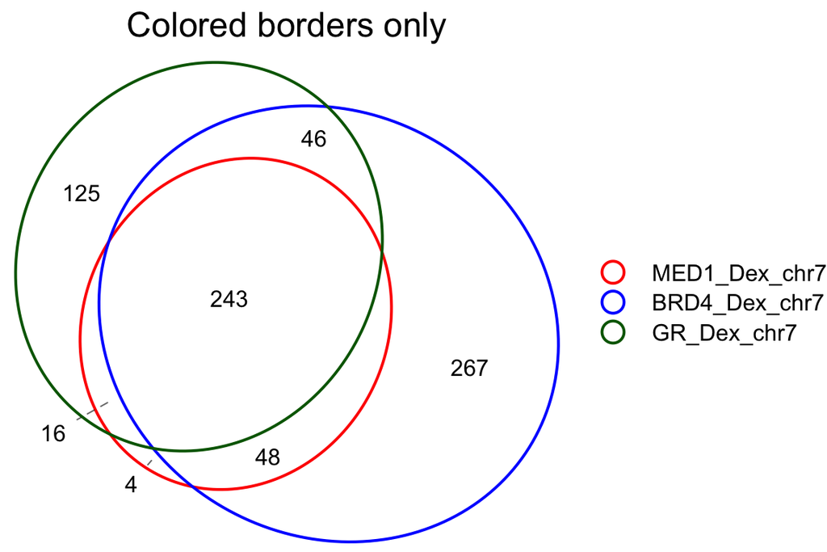

```r
plotVenn(genomic_overlaps,
         fills = "transparent",
         edges = list(col = c("red", "blue", "darkgreen"), lwd = 2),
         main = list(label = "Colored borders only"))
```

## 10.3 Custom labels and counts + percentages

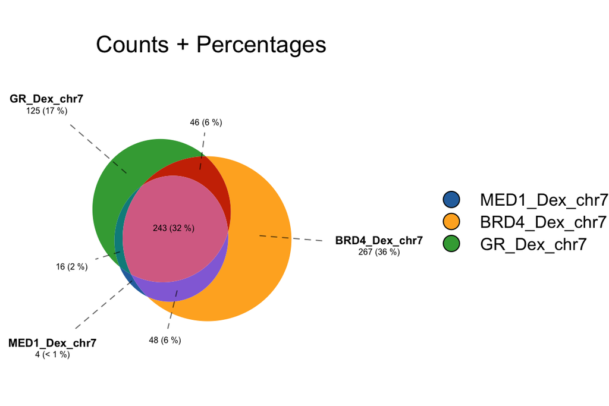

```r
plotVenn(genomic_overlaps,
         labels = list(col = "black", fontsize = 8, font = 2),
         quantities = list(type = c("counts","percent"),
                           col = "black", fontsize = 6),
         main = list(label = "Counts + Percentages", fontsize = 11))
```

## 10.4 Legend at the bottom with custom text

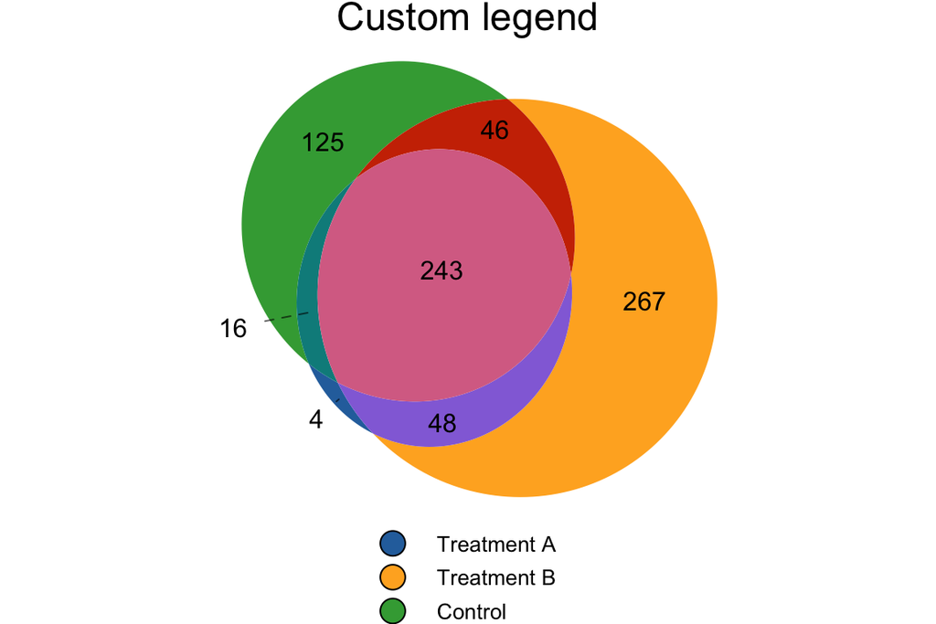

```r
plotVenn(genomic_overlaps,
         legend = list(side = "bottom",
                       labels = c("Treatment A","Treatment B","Control"),
                       fontsize = 10),
         main = list(label = "Custom legend"))
```

## 10.5 Combining multiple custom options

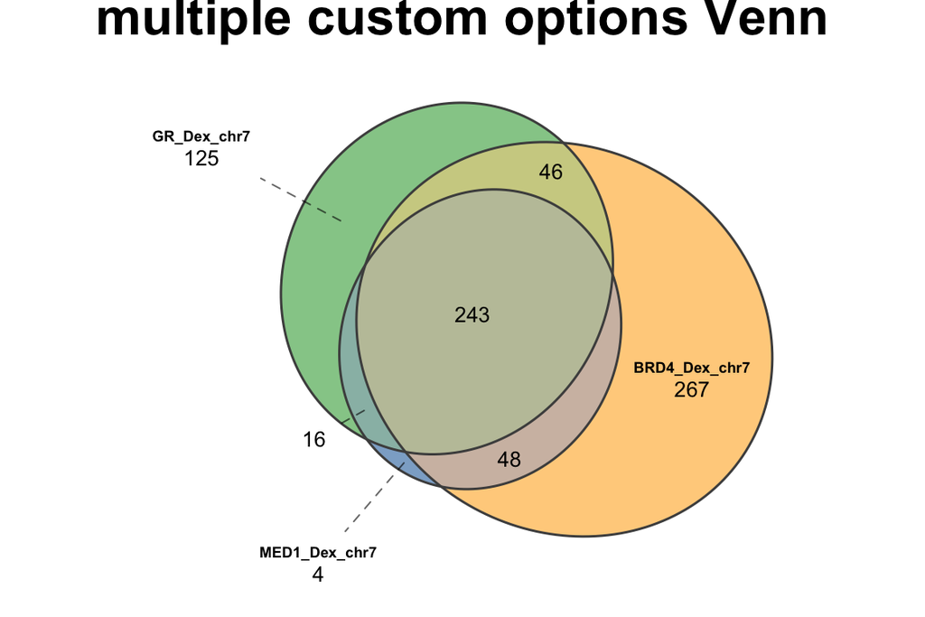

```r
plotVenn(genomic_overlaps,
         fills = list(fill = c("#2B70AB", "#FFB027", "#3EA742"), alpha = 0.6),
         edges = list(col = "gray30", lwd = 1.5),
         labels = list(col = "black", fontsize = 7, font = 2),
         quantities = list(type = "counts", col = "black", fontsize = 10),
         main = list(label = "multiple custom options Venn", fontsize = 16, font = 2),
         legend = FALSE)
```

# 11 References

For more information about the gVenn package, visit:

- Package documentation: https://ckntav.github.io/gVenn
- GitHub repository: https://github.com/ckntav/gVenn

© 2026 [Christophe Tav](https://ckntav.github.io/)